# Biweekly report: Functionalised graphene for polymer composites

Emil Tveden Bjerglund

19 jan 2018

Several groups have shown great interest in our work with production of functionalised graphene for polymer composites.

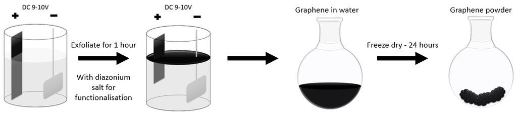

In this project we will attempt to produce batches for testing in various companies with various goals:

- Radisurf (Intends to do ATRP-polymerisation on the graphene and embed it in silicone).
- SP Group (Interest in testing it for their PUR products).
- Newtec (Interest in graphene with different functionalities for better interaction with their quantum dots).
- Chemical Engineers, AU (Repetition of our work in Andreas’ bachelorproject for potential publication).

These projects will hopefully give some more experience in handling large quantities of graphene and give some interesting applications.

Lab journal available at https://emiltb.github.io/graphene-production/lab_journal.html

# Planned experiments from last biweekly report

- Isolate the current batch of graphene and analyse it.
- Given that this production is succesful, I just need to run several more of the same as quickly as possible to deliver to Radisurf, SP Group and the Chemical Engineers.

# Large scale graphene production

- I now have a pretty solid procedure for large scale exfoliation of functionalised graphene. I can exfoliate approx. 5 g/hr, and then it takes another day to do ultrasonication, centrifugation and freeze-drying.
- Current I am focusing on making amine-functionalised graphene for SP Group and Radisurf.
- For all experiments I monitor the diazonium concentration by extracting samples and reacting with 2-Naphtol to form an azo-dye. This seems to work well, and allows us to know the exact concentration during exfoliation and how it develops during the experiment.

I current have approx. 20 g that will be processed over the weekend to form the final graphene.

## Challenges

Currently the two main challenges in processing the graphene is ultrasonication and freeze-drying.

Ultrasonication has been mostly solved by using a probe-type ultrasonicator at the inorganic department. It seems to work well, but I have not done extensive testing to optimise parameters (concentrations, time, volume).

Freeze-drying is still posing problems for me. Lately I have had succes with freeze-drying approx. 1 g of material in 100 mL water by spin-freezing in a 500 mL flask and wrapping the flask in paper an alu-foil to insulate it, before putting on the freeze-dryer. This seems to help with the samples drying, but I still sometimes have samples failing due to thawing, and that renders the produced graphene unusable, since it cannot easily be dispersed in solvents again. I still wish to scale this process up a couple of factors to make handling large samples easier.

# Plan for the next two weeks

- Characterisation of the amine-functionalised graphene.
- Meetings with SP Group and Radisurf to discuss which experiments they will make with the graphene.